# Proyecto Final | Series de Tiempo

Diplomado en Técnicas Estadísticas y de Mineria de Datos

Equipo 1

16 de julio de 2022

**Equipo 1**

- Abimael de la Cruz Jiménez
- Alfonso Flores Zenteno
- Ana Saharaí Hernández Delgadillo
- Ana Karen Picazo Ayala
- Brenda Durán Díaz
- Ivan Moises Hita Cahuantzi
- Ricardo Hernández Gaona

# Introducción

La información analizada contempla datos históricos que abarcan las ventas del 05-02-2010 hasta 01-11-2012, en el archivo con el nombre WalmartStoreSales. En el archivo se encontrarán las siguientes variables:

- VENTAS_SEMANALES: Esta variable registra el monto de las ventas de cada semana.
- PRECIO_COMBUSTRIBLE: Es el precio de la gasolina en la región. Se registra el monto del precio en dólares por galón.
- CPI: Es el índice de precios al consumidor.
- TEMPERATURA: La temperatura del día de la venta registrada en grados Fahrenheit.
- DESEMPLEO: Marca la tasa de desempleo predominante durante esa semana.
- TIENDA: Se refiere al número de tienda. En total tenemos los registros de 45 tiendas, por lo que esta columna toma valores de 1 a 45.
- FECHA: Se refiere a la semana en la que se registró la venta, se pone la fecha del viernes de esa semana.

# Análisis exploratorio

Análisis Exploratorio, se tomaron en consideración las variables con outliers: Unemployment, Fuel_price y CPI. Se generó una tabla de correlación para observar la posible influencia de las variables y tratar de predecir cuáles serían de utilidad para el modelo. Decidimos utilizar la tasa de desempleo, el precio del combustible y la semana del año para tratar de explicar el comportamiento de ventas.

```r
# Verificamos si hay datos nulos
colSums(is.na(data1))
```

```
##        Store         Date Weekly_Sales Holiday_Flag  Temperature   Fuel_Price
##            0            0            0            0            0            0
##          CPI Unemployment
##            0            0
```

```r
# Verificamos si hay datos duplicados
all(duplicated(data1) == TRUE)
```

```
## [1] FALSE
```

```r
# Generamos un objeto que acumule las ventas por tienda
Store_Sales<- aggregate(Weekly_Sales ~ Store, data = data1, sum)
colnames(Store_Sales)[2] <- "Total_Sales_by_Store"

Store_Sales <- arrange(Store_Sales, desc(Total_Sales_by_Store))

print(paste('La tienda número ', Store_Sales[1,]$Store,
            'tiene las mayores ventas con un valor de : ', Store_Sales[1,]$Total_Sales_by_Store))
```

```
## [1] "La tienda número  20 tiene las mayores ventas con un valor de :  301397792.46"
```

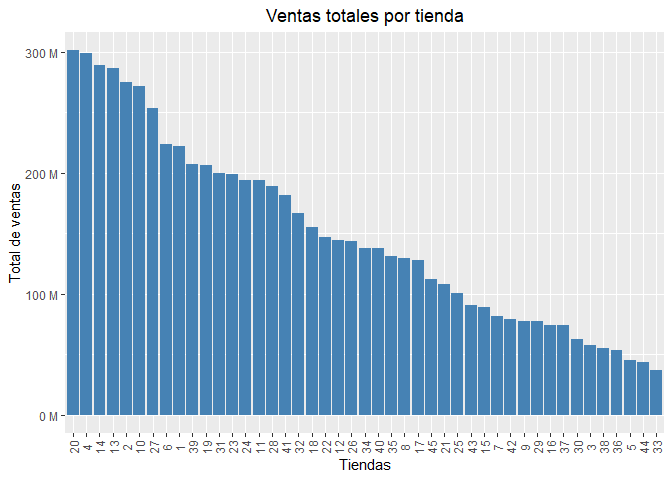

```r
# Gráfica de ventas totales por tienda

Store_Sales$Store <- as.character(Store_Sales$Store)
Store_Sales$Store <- factor(Store_Sales$Store, levels=unique(Store_Sales$Store))

options(repr.plot.width = 14, repr.plot.height = 8)

graficaVentasTienda <- ggplot(data=Store_Sales, aes(x=Store, y=Total_Sales_by_Store)) + geom_bar(stat="identity",fill="steelblue") +
  theme(axis.text.x = element_text(angle = 90,vjust = 0.5, hjust=0.5))+ scale_x_discrete(breaks = data1$Store)+
  scale_y_continuous(labels = label_number(suffix = " M", scale = 1e-6))+ ggtitle('Ventas totales por tienda')+
  theme(plot.title = element_text(hjust = 0.5))+
  xlab("Tiendas") + ylab("Total de ventas")

graficaVentasTienda
```

```r
alterData <- data1

# Usamos la tienda número uno
alterData <- dplyr::filter(alterData, Store ==1)

# Cambiamos el formato de fecha y ordenamos de menor a mayor
alterData$Date <- lubridate::dmy(alterData$Date)
alterData <- dplyr::arrange(alterData,Date)

# Creamos columnas para número de semana, mes y cuarto del año
alterData$Week_Number <- seq(1:length(unique(alterData$Date)))
alterData$month <- lubridate::month(alterData$Date)
alterData$quarter <- lubridate::quarter(alterData$Date)

# Creating a event type dataframe

# Vector con fechas festivas en estados unidos
Holiday_date <- c("12-02-2010", "11-02-2011", "10-02-2012", "08-02-2013","10-09-2010", "09-09-2011", "07-09-2012", "06-09-2013","26-11-2010", "25-11-2011", "23-11-2012", "29-11-2013","31-12-2010", "30-12-2011", "28-12-2012", "27-12-2013")
Holiday_date <- lubridate::dmy(Holiday_date)

# Etiquetas de los eventos
Events <- c(rep("Super Bowl", 4), rep("Labour Day", 4),rep("Thanksgiving", 4), rep("Christmas", 4))

# Data frame de eventos y fechas
Holidays_Data <- data.frame(Events,Holiday_date)

# Combinamos data frames
alterData <- merge(alterData,Holidays_Data, by.x="Date", by.y="Holiday_date", all.x = TRUE)

# En las semanas sin eventos ponemos una etiqueta
alterData$Events = as.character(alterData$Events)
alterData$Events[is.na(alterData$Events)]= "No_Holiday"

head(alterData)
```

```
##         Date Store Weekly_Sales Holiday_Flag Temperature Fuel_Price      CPI
## 1 2010-02-05     1      1643691            0       42.31      2.572 211.0964
## 2 2010-02-12     1      1641957            1       38.51      2.548 211.2422
## 3 2010-02-19     1      1611968            0       39.93      2.514 211.2891
## 4 2010-02-26     1      1409728            0       46.63      2.561 211.3196
## 5 2010-03-05     1      1554807            0       46.50      2.625 211.3501
## 6 2010-03-12     1      1439542            0       57.79      2.667 211.3806
##   Unemployment Week_Number month quarter     Events
## 1        8.106           1     2       1 No_Holiday
## 2        8.106           2     2       1 Super Bowl
## 3        8.106           3     2       1 No_Holiday
## 4        8.106           4     2       1 No_Holiday
## 5        8.106           5     3       1 No_Holiday
## 6        8.106           6     3       1 No_Holiday
```

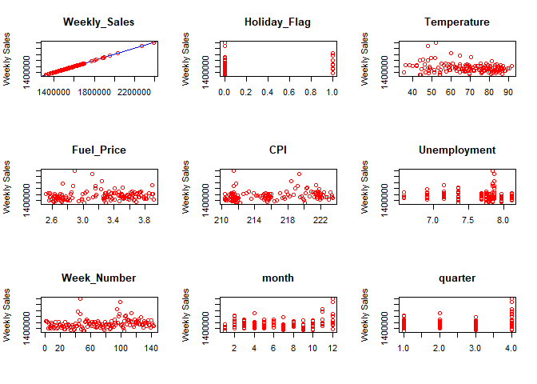

```r
# Graficamos las ventas semanales contra todas las variables
par(mfrow=c(3,3))
for(i in 3:11){
  plot(alterData[,i],
       alterData$Weekly_Sales,
       main=names(alterData[i]),
       ylab="Weekly Sales", xlab =" ",
       col='red',
       abline(lm(alterData[,i] ~ alterData$Weekly_Sales, data = alterData), col = "blue"))
}
```

```r
par(mfrow=c(1,1))
```

## Buscando Outliers por variable contra Ventas semanales

Buscaremos outliers en las diferentes variables

```r
# Creamos otro data frame para limpiarlo
cleanedData <- alterData
```

### Temperatura

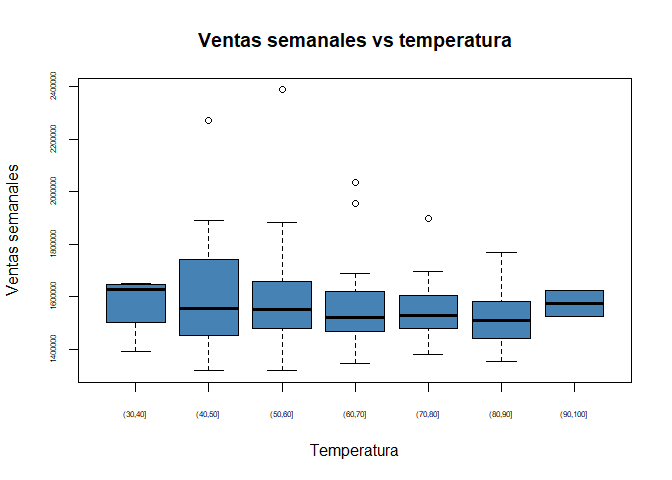

```r
# En la variable de temperatura se encontraron 5 outliers

boxplot(cleanedData$Weekly_Sales ~ cut(cleanedData$Temperature, pretty(cleanedData$Temperature)), main="Ventas semanales vs temperatura", xlab ="Temperatura", ylab="Ventas semanales", cex.axis=0.5, col="Steel Blue")
```

```r
outliers_temp <- boxplot(cleanedData$Weekly_Sales ~ cut(cleanedData$Temperature, pretty(cleanedData$Temperature)), main="Ventas semanales vs temperatura", cex.axis=0.5,plot=FALSE)$out

cleanedData<- cleanedData[-which(cleanedData$Weekly_Sales %in% outliers_temp),]
```

### CPI

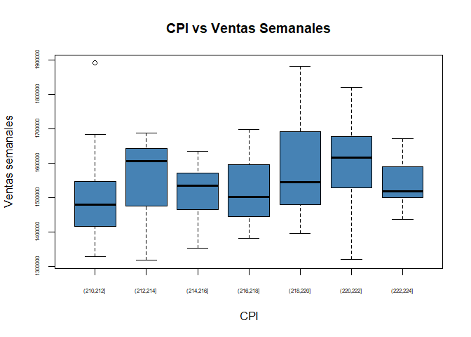

```r
# En la variable CPI se encontró un outlier
boxplot(cleanedData$Weekly_Sales ~ cut(cleanedData$CPI, pretty(cleanedData$CPI)), main="CPI vs Ventas Semanales",xlab ="CPI", ylab="Ventas semanales", cex.axis=0.5,col="Steel Blue")
```

```r
outliers_CPI <- boxplot(cleanedData$Weekly_Sales ~ cut(cleanedData$CPI, pretty(cleanedData$CPI)), main="CPI vs Ventas Semanales", cex.axis=0.5,plot=FALSE)$out

cleanedData <- cleanedData[-which(cleanedData$Weekly_Sales %in% outliers_CPI),]
```

### Tasa de Desempleo

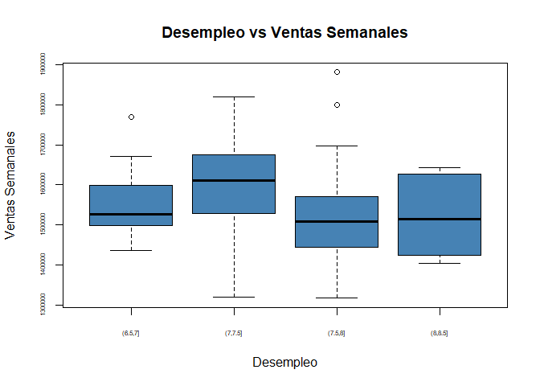

```r
# Se encontraron 3 outliers en la variable Desempleo
boxplot(cleanedData$Weekly_Sales ~ cut(cleanedData$Unemployment, pretty(cleanedData$Unemployment)), main="Desempleo vs Ventas Semanales",xlab ="Desempleo", ylab="Ventas Semanales",  cex.axis=0.5, col="Steel Blue")
```

```r
outliers_Unemployment <- boxplot(cleanedData$Weekly_Sales ~ cut(cleanedData$Unemployment, pretty(cleanedData$Unemployment)), main="Desempleo vs Ventas Semanales", cex.axis=0.5,plot=FALSE)$out

cleanedData <- cleanedData[-which(cleanedData$Weekly_Sales %in% outliers_Unemployment),]
```

### Precio del combustible

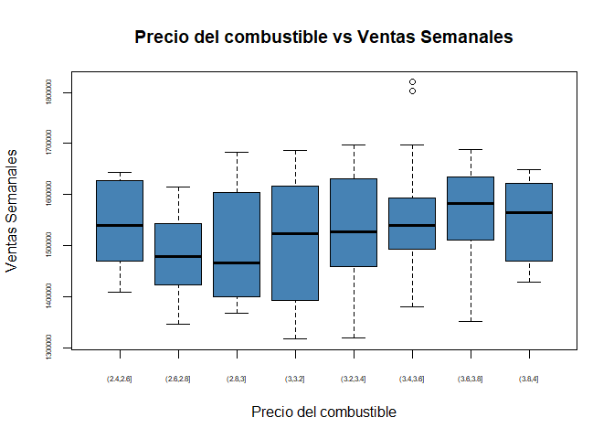

```r
# Se encontraron dos outliers en la variable Precio del combustible
boxplot(cleanedData$Weekly_Sales ~ cut(cleanedData$Fuel_Price, pretty(cleanedData$Fuel_Price) ), main="Precio del combustible vs Ventas Semanales", xlab ="Precio del combustible", ylab="Ventas Semanales", cex.axis=0.5,col="Steel Blue")
```

```r
outliers_fuel_price <- boxplot(cleanedData$Weekly_Sales ~ cut(cleanedData$Fuel_Price, pretty(cleanedData$Fuel_Price)), main="Precio del combustible vs Ventas Semanales", cex.axis=0.5,plot=FALSE)$out

cleanedData <- cleanedData[-which(cleanedData$Weekly_Sales %in% outliers_fuel_price),]
```

### Feriados

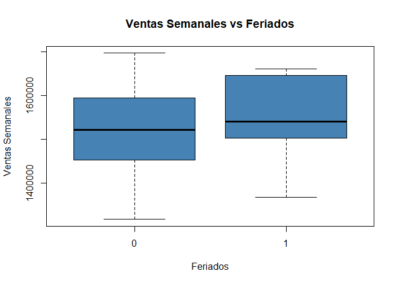

```r
# No se encuentran outliers para la variable de detección de día feriado
boxplot(cleanedData$Weekly_Sales ~ cleanedData$Holiday_Flag, main = 'Ventas Semanales vs Feriados',xlab ="Feriados", ylab="Ventas Semanales",col="Steel Blue" )
```

### Mes

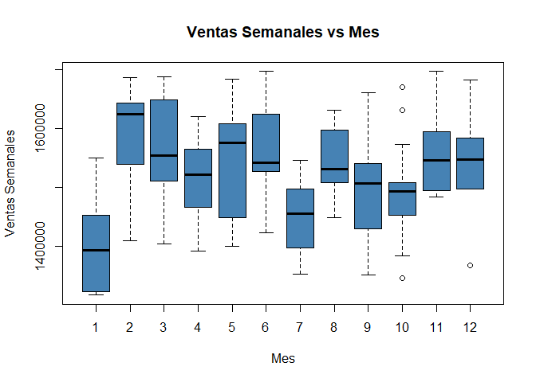

```r
# Ventas Semanales por la variable mes, se eliminan 4 outliers
boxplot(cleanedData$Weekly_Sales ~ cleanedData$month, main = 'Ventas Semanales vs Mes', xlab ="Mes", ylab="Ventas Semanales", col="Steel Blue")
```

```r
outliers_month <- boxplot(cleanedData$Weekly_Sales ~ cleanedData$month, main = 'Ventas Semanales vs Mes',plot=FALSE)$out
cleanedData<- cleanedData[-which(cleanedData$Weekly_Sales %in% outliers_month),]
```

### Cuarto

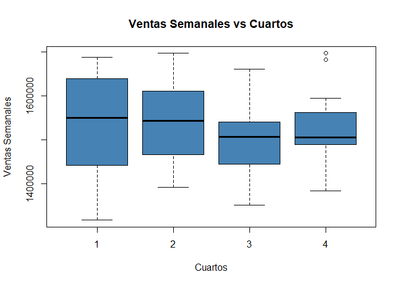

```r
# Dos outliers al hacer el tratamiento por la variable de cuarto de año
outliers_quarter <- boxplot(cleanedData$Weekly_Sales ~ cleanedData$quarter, main = 'Ventas Semanales vs Cuartos',xlab ="Cuartos", ylab="Ventas Semanales", col="Steel Blue")$out
```

```r
cleanedData<- cleanedData[-which(cleanedData$Weekly_Sales %in% outliers_quarter),]
```

## Modificación de data frame

Removemos columnas innecesarias y cambiamos un poco la estructura de la variable Evento y modificamos los valores de las otras variables para trabajar mejor con ellas.

```r
cleanedData$Date <- NULL
cleanedData$Store <- NULL
cleanedData$Events <- as.factor(cleanedData$Events)
cleanedData$Holiday_Flag <- as.numeric(cleanedData$Holiday_Flag)
cleanedData$Week_Number <- as.numeric(cleanedData$Week_Number)
cleanedData$quarter <- as.numeric(cleanedData$quarter)
str(cleanedData)
```

```
## 'data.frame':    126 obs. of  10 variables:
##  $ Weekly_Sales: num  1643691 1641957 1611968 1409728 1554807 ...
##  $ Holiday_Flag: num  0 1 0 0 0 0 0 0 0 0 ...
##  $ Temperature : num  42.3 38.5 39.9 46.6 46.5 ...
##  $ Fuel_Price  : num  2.57 2.55 2.51 2.56 2.62 ...
##  $ CPI         : num  211 211 211 211 211 ...
##  $ Unemployment: num  8.11 8.11 8.11 8.11 8.11 ...
##  $ Week_Number : num  1 2 3 4 5 6 7 8 9 10 ...
##  $ month       : num  2 2 2 2 3 3 3 3 4 4 ...
##  $ quarter     : num  1 1 1 1 1 1 1 1 2 2 ...
##  $ Events      : Factor w/ 4 levels "Christmas","Labour Day",..: 3 4 3 3 3 3 3 3 3 3 ...
```

## Matriz de correlación

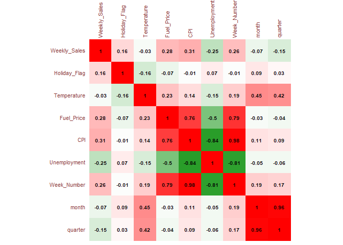

```r
# Creamos una matrix de correlación
corr = cor(cleanedData[, c(1:9)])
View(corr)
corrplot(corr, method = "color", cl.pos = 'n', rect.col = "black",  tl.col = "indianred4", addCoef.col = "black", number.digits = 2, number.cex = 0.60, tl.cex = 0.7, cl.cex = 1, col = colorRampPalette(c("green4","white","red"))(100))
```

Con esta matriz de correlación nos damos cuenta que las correlaciones más fuertes están entre las variables Número de semana con precio de combustible, Número de semana con CPI, Número de semana con tasa de desempleo, Tasa de desempleo con CPI, Precio de combustible con CPI.

# Regresión Lineal

## Modelo Simple

Interpretación

- Si los parámetros son igual a cero, la venta semanal incrementa en 340,219.1226 dólares.
- Si el Fuel_Price incrementa en una unidad, entonces las ventas semanales incrementan 27,671.8389 dólares
- Si el desempleo incrementa en una unidad , entonces se tendría una disminución de las ventas de 30,766.7480 dólares.

**R-Cuadrada**: Representa que tan cerca están los datos de la línea de regresión ajustada. El 48% explica la variabilidad de los datos de respuesta en torno a su media.

**R Cuadrado Ajustado**: Representa la extensión de la varianza de la variable dependiente que pueda explicarse por la variable independiente. El 38% de la variación en la variable dependiente se explica por la variable independiente.

```r
model = lm(formula = Weekly_Sales ~ . , data = cleanedData)
model$coefficients
```

[output not shown]

```r
summary(model)
```

[output not shown]

## Modelo Lin-Lin

Modelo Lin-Lin, en este modelo su especificación contempla que tanto para la variable dependiente, cómo para la variables independientes o explicativas se contemplan lineales.

La especificación del modelo consiste en las ventas semanales cómo variable dependiente, al precio del combustible (Fuel Price), el Desempleo (Unemployment) y el número de la semana cómo variable explicativa.

El modelo así especificado reportó significativa al intercepto con un P-value menor 3.78e-09, también el precio del combustible con su P-value de 0.062, mostrando también su significancia cómo variable explicativa. Sin embargo, el desempleo y el no. de la semana no demostraron ser significativas para el modelo.

Para el modelo su R ^2 de 0.098 indicando que sólo el 9.8% de los datos de las ventas semanales resultaron explicados por el modelo.

```r
modLin <- lm(cleanedData$Weekly_Sales~cleanedData$Fuel_Price+cleanedData$Unemployment+cleanedData$Week_Number)
modLin$coefficients
```

```
##              (Intercept)   cleanedData$Fuel_Price cleanedData$Unemployment
##              1774572.607                57189.381               -54727.734
##  cleanedData$Week_Number
##                 -324.265
```

```r
summary(modLin)
```

```
##
## Call:
## lm(formula = cleanedData$Weekly_Sales ~ cleanedData$Fuel_Price +
##     cleanedData$Unemployment + cleanedData$Week_Number)
##
## Residuals:
##     Min      1Q  Median      3Q     Max
## -207537  -63181    5174   54945  179665
##
## Coefficients:
##                           Estimate Std. Error t value Pr(>|t|)
## (Intercept)              1774572.6   279303.2   6.354 3.78e-09 ***
## cleanedData$Fuel_Price     57189.4    30365.9   1.883    0.062 .
## cleanedData$Unemployment  -54727.7    36744.7  -1.489    0.139
## cleanedData$Week_Number     -324.3      465.2  -0.697    0.487
## ---
## Signif. codes:  0 '***' 0.001 '**' 0.01 '*' 0.05 '.' 0.1 ' ' 1
##
## Residual standard error: 85710 on 122 degrees of freedom
## Multiple R-squared:  0.09827,    Adjusted R-squared:  0.0761
## F-statistic: 4.432 on 3 and 122 DF,  p-value: 0.005405
```

## Modelo Log-Log

Modelo Log Log, este modelo consiste en utilizar el logaritmo de la variable explicativa y de la variables independientes.

Su especificación toma a las ventas semanales cómo dependiente y al precio de combustible, tasa de desempleo y al número de la semana cómo independiente o explicativa.

El modelo reportó significancia para todas sus variables. Para este modelo su R ^2 de 0.1312 indicando que sólo el 13.12% de los datos resultaron explicados por el modelo así especificado.

```r
modLog <- lm(log(cleanedData$Weekly_Sales)~log(cleanedData$Fuel_Price)+log(cleanedData$Unemployment)+log(cleanedData$Week_Number) )
modLog$coefficients
```

```
##                   (Intercept)   log(cleanedData$Fuel_Price)
##                   14.72389809                    0.17719161
## log(cleanedData$Unemployment)  log(cleanedData$Week_Number)
##                   -0.30208009                   -0.02151658
```

```r
summary(modLog)
```

```
##
## Call:
## lm(formula = log(cleanedData$Weekly_Sales) ~ log(cleanedData$Fuel_Price) +
##     log(cleanedData$Unemployment) + log(cleanedData$Week_Number))
##
## Residuals:
##       Min        1Q    Median        3Q       Max
## -0.139874 -0.041158  0.006642  0.040828  0.121647
##
## Coefficients:
##                                Estimate Std. Error t value Pr(>|t|)
## (Intercept)                   14.723898   0.273504  53.834  < 2e-16 ***
## log(cleanedData$Fuel_Price)    0.177192   0.057064   3.105  0.00237 **
## log(cleanedData$Unemployment) -0.302080   0.124543  -2.426  0.01675 *
## log(cleanedData$Week_Number)  -0.021517   0.009068  -2.373  0.01922 *
## ---
## Signif. codes:  0 '***' 0.001 '**' 0.01 '*' 0.05 '.' 0.1 ' ' 1
##
## Residual standard error: 0.05571 on 122 degrees of freedom
## Multiple R-squared:  0.1312, Adjusted R-squared:  0.1098
## F-statistic: 6.139 on 3 and 122 DF,  p-value: 0.0006361
```

Graficamos los residuales del modelo

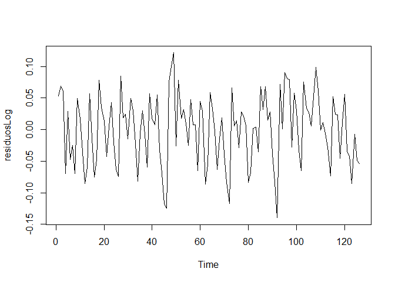

```r
residuosLog <- modLog$residuals
ts.plot(residuosLog)
```

```r
auto.arima(residuosLog)
```

```
## Series: residuosLog
## ARIMA(0,0,3) with zero mean
##
## Coefficients:
##          ma1      ma2      ma3
##       0.3466  -0.0339  -0.3892
## s.e.  0.0888   0.0826   0.0940
##
## sigma^2 = 0.002562:  log likelihood = 198.33
## AIC=-388.65   AICc=-388.32   BIC=-377.31
```

Construimos nuevo modelo con la predicción para la siguiente semana

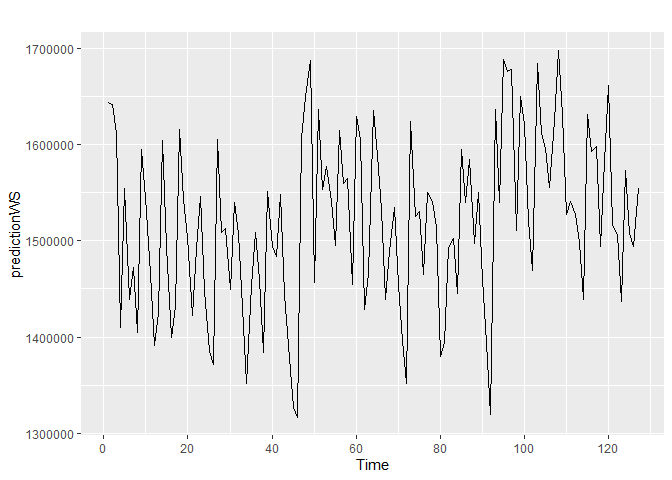

```r
modeloRL <- arima(residuosLog, order=c(2,0,2))

# Predición para la semana 139
prediccion1 <- predict(modeloRL, h=1)


# Predicción Mod Log-Log
prediccionModLog <- predict(modLog)

# Añadimos la predicción de la semana 139 a las observaciones
newObs <- c(cleanedData$Weekly_Sales, exp(14.27747 + predict(modeloRL, h=1)$pred[1]) )

predictionWS <- ts(newObs)

autoplot(predictionWS)
```

## Modelo Estandarizado

Se propone la siguiente prueba de Hipótesis

$$H_{0} = 0 \\
H_{a} <> 0$$

```r
Mean_ws <- mean(cleanedData$Weekly_Sales)
Sd_ws <- sd(cleanedData$Weekly_Sales)

Mean_fuel <- mean(cleanedData$Fuel_Price)
Sd_fuel <- sd(cleanedData$Fuel_Price)

Mean_unemp <- mean(cleanedData$Unemployment)
Sd_unemp <- sd(cleanedData$Unemployment)

Mean_week <- mean(cleanedData$Week_Number)
Sd_week <- sd(cleanedData$Week_Number)

norm_ws <- (cleanedData$Weekly_Sales - Mean_ws) / Sd_ws;
norm_fuel <- (cleanedData$Fuel_Price - Mean_fuel) / Sd_fuel;
norm_unemp <- (cleanedData$Unemployment - Mean_unemp) / Sd_unemp;
norm_week <- (cleanedData$Week_Number - Mean_week) / Sd_week;

modNorm <- lm(norm_ws~norm_fuel+norm_unemp+norm_week-1)

format(modNorm$coefficients, scientific = FALSE)
```

```
##    norm_fuel   norm_unemp    norm_week
## " 0.2823382" "-0.2347135" "-0.1538392"
```

```r
modNorm$coefficients
```

```
##  norm_fuel norm_unemp  norm_week
##  0.2823382 -0.2347135 -0.1538392
```

```r
summary(modNorm)
```

```
##
## Call:
## lm(formula = norm_ws ~ norm_fuel + norm_unemp + norm_week - 1)
##
## Residuals:
##      Min       1Q   Median       3Q      Max
## -2.32735 -0.70852  0.05802  0.61616  2.01479
##
## Coefficients:
##            Estimate Std. Error t value Pr(>|t|)
## norm_fuel    0.2823     0.1493   1.891    0.061 .
## norm_unemp  -0.2347     0.1569  -1.495    0.137
## norm_week   -0.1538     0.2198  -0.700    0.485
## ---
## Signif. codes:  0 '***' 0.001 '**' 0.01 '*' 0.05 '.' 0.1 ' ' 1
##
## Residual standard error: 0.9573 on 123 degrees of freedom
## Multiple R-squared:  0.09827,    Adjusted R-squared:  0.07628
## F-statistic: 4.468 on 3 and 123 DF,  p-value: 0.005151
```

# Series de Tiempo

## Promedio Simple de Ventas Semanales

Representación gráfica de la variable ventas de la tienda número 1 (Walmart$Store$Weekly_Sales) la serie de tiempo con periodicidad semanal se define como (start = decimal_date(as.Date(“2010-02-05”)), frequency = 52)

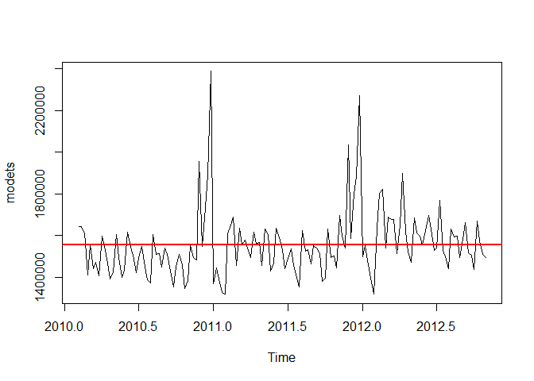

```r
# Actualizacion de inicio y Frecuencia
info_tda_1 <- Walmart[Walmart$Store == '1',];
modets <- ts(info_tda_1$Weekly_Sales,start = decimal_date(as.Date("2010-02-05")), frequency = 52);

# Gráfica
ts.plot(modets)
qqline(mean(modets), col="Red", lwd=2)
```

A continuación se presentan los diferentes modelos trabajados, graficados y con la tabla de error. La interpretación para cada uno de estos se debe entender de la siguiente forma:

> El modelo acepta una tolerancia del error de hasta (MAPE) por ciento (%), lo que representa un error mínimo en Millones de dólares (MAE) y un máximo en millones de dólares de (RMSE)

## Promedio Movil

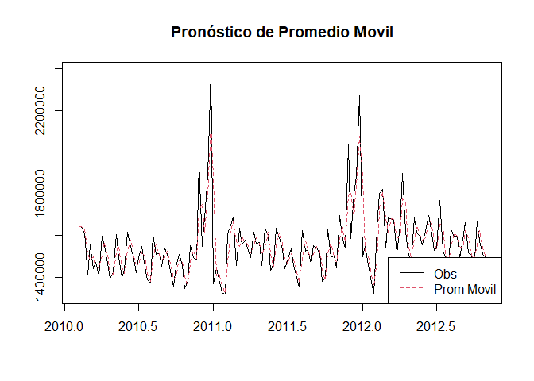

```r
Prom_Movil_2 <- movavg(modets,2,type="s");
ts.plot(modets,Prom_Movil_2,xlab=NULL,ylab=NULL, main = "Pronóstico de Promedio Movil",lty=c(1:2),lwd =c(1,1.5) ,col=c(1,2))
legend(x="bottomright",legend=c("Obs","Prom Movil"),col=c(1,2),lty=c(1,2))
```

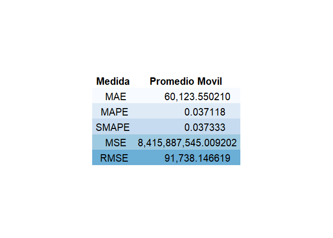

```r
#Errores
mae <- MAE(modets,Prom_Movil_2);
mape <- MAPE(modets,Prom_Movil_2);
smape <- SMAPE(modets,Prom_Movil_2);
mse <- MSE(modets,Prom_Movil_2);
rmse <- RMSE(modets,Prom_Movil_2);
medidas <- matrix(c(mae,mape,smape,mse,rmse));
rownames(medidas) <- c('MAE','MAPE','SMAPE','MSE','RMSE')
colnames(medidas)<-c("Prom.Simple")
df_medidas <- as.data.frame(medidas)

tab_medidas <- as.data.table(df_medidas, keep.rownames=TRUE, keep.colnames=FALSE)
colnames(tab_medidas) <- c("Medida","Promedio Movil ")
ftab_medidas <- format(tab_medidas, digits=5, scientific = F, big.mark=",",decimal.mark=".",justify="right")
tem <- ttheme_minimal(base_colour="black",base_size=15, core=list(bg_params=list(fill=blues9,col=NA)))

grid.arrange(tableGrob(ftab_medidas,theme=tem))
```

## Promedio Ponderado

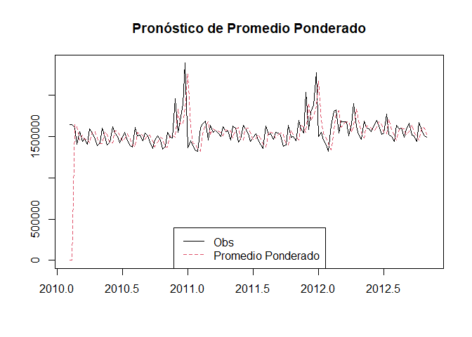

```r
y <- ts(info_tda_1$Weekly_Sales, start = decimal_date(as.Date("2010-02-05")), frequency = 52)

f<-rep(0,144)
for (t in 3:144) f[t]<-(0.75)*y[t-1]+(0.25)*y[t-2]

f <- ts(f, start = decimal_date(as.Date("2010-02-05")), frequency = 52)

ts.plot(y,f,xlab=NULL,ylab=NULL, main = "Pronóstico de Promedio Ponderado",lty=c(1:2),lwd =c(1,1.5) ,col=c(1,2))
legend(x="bottom",legend=c("Obs","Promedio Ponderado"),col=c(1,2),lty=c(1,2))
```

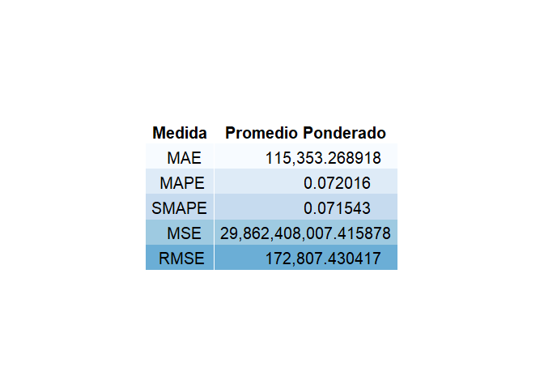

```r
yp_ob<-rep(0,141)
for (t in 1:141) yp_ob[t]<-y[t+2]

yp_pr<-rep(0,141)
for (t in 1:141) yp_pr[t]<-f[t+2]

mae_yp<-MAE(yp_ob,yp_pr)
mape_yp<-MAPE(yp_ob,yp_pr)
smape_yp<-SMAPE(yp_ob,yp_pr)
mse_yp<-MSE(yp_ob,yp_pr)
rmse_yp<-RMSE(yp_ob,yp_pr)

medidas <- matrix(c(mae_yp,mape_yp,smape_yp,mse_yp,rmse_yp))
rownames(medidas) <- c('MAE','MAPE','SMAPE','MSE','RMSE')
colnames(medidas)<-c("Promedio Ponderado")
df_medidas <- as.data.frame(medidas)

tab_medidas <- as.data.table(df_medidas, keep.rownames=TRUE, keep.colnames=FALSE)
colnames(tab_medidas) <- c("Medida","Promedio Ponderado")
ftab_medidas <- format(tab_medidas, digits=5, scientific = F, big.mark=",",decimal.mark=".",justify="right")
tem <- ttheme_minimal(base_colour="black",base_size=15, core=list(bg_params=list(fill=blues9,col=NA)))

grid.arrange(tableGrob(ftab_medidas,theme=tem))
```

## Media móvil tipo “w”

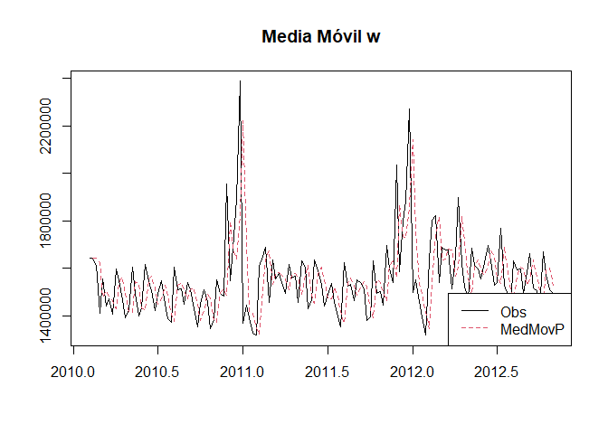

```r
fw<-movavg(y,2,type="w")
fwt<-rep(0,143)
for(t in 2:143) fwt[t]<-fw[t-1]
for(t in 1) fwt[t]<-NA
fw_ts<-rep(0,143)
fw_ts<-ts(fwt,start = decimal_date(as.Date("2010-02-05")), frequency = 52)

ts.plot(y,fw_ts,xlab=NULL,ylab=NULL, main = "Media Móvil w",lty=c(1:2),col=c(1,2))
legend(x="bottomright",legend=c("Obs","MedMovP"),col=c(1,2),lty=c(1,2))
```

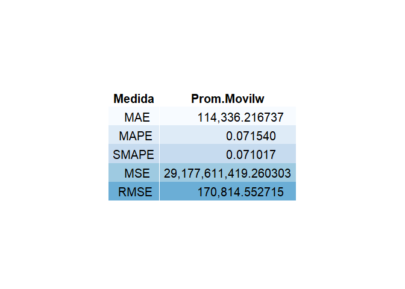

```r
yw_ob<-rep(0,142)
for (t in 1:142) yw_ob[t]<-y[t+1]
yw_pr<-rep(0,142)
for (t in 1:142) yw_pr[t]<-fw[t]
mae_yw<-MAE(yw_ob,yw_pr)
mape_yw<-MAPE(yw_ob,yw_pr)
smape_yw<-SMAPE(yw_ob,yw_pr)
mse_yw<-MSE(yw_ob,yw_pr)
rmse_yw<-RMSE(yw_ob,yw_pr)

medidas <- matrix(c(mae_yw,mape_yw,smape_yw,mse_yw,rmse_yw));
rownames(medidas) <- c('MAE','MAPE','SMAPE','MSE','RMSE')
colnames(medidas)<-c("Prom.Movilw")
df_medidas <- as.data.frame(medidas)

tab_medidas <- as.data.table(df_medidas, keep.rownames=TRUE, keep.colnames=FALSE)
colnames(tab_medidas) <- c("Medida","Prom.Movilw")
ftab_medidas <- format(tab_medidas, digits=5, scientific = F, big.mark=",",decimal.mark=".",justify="right")
tem <- ttheme_minimal(base_colour="black",base_size=15, core=list(bg_params=list(fill=blues9,col=NA)))

grid.arrange(tableGrob(ftab_medidas,theme=tem))
```

## Media móvil tipo “e”

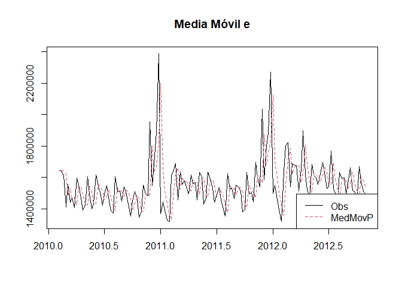

```r
fe<-movavg(y,2,type="e")
fet<-rep(0,143)
for(t in 2:143) fet[t]<-fe[t-1]
for(t in 1) fet[t]<-NA
fe_ts<-rep(0,143)
fe_ts<-ts(fet,start = decimal_date(as.Date("2010-02-05")), frequency = 52)

ts.plot(y,fe_ts,xlab=NULL,ylab=NULL, main = "Media Móvil e",lty=c(1:2),col=c(1,2))
legend(x="bottomright",legend=c("Obs","MedMovP"),col=c(1,2),lty=c(1,2))
```

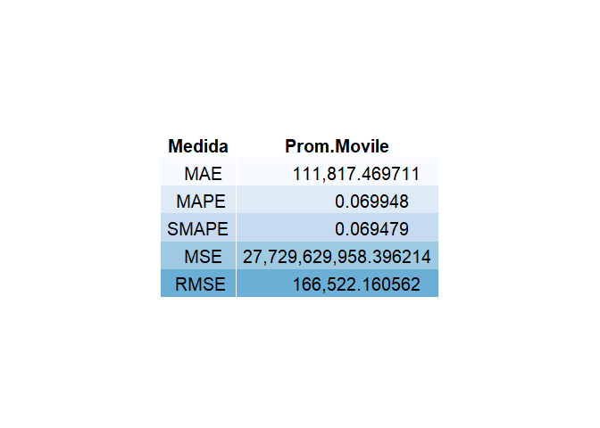

```r
ye_ob<-rep(0,142)
for (t in 1:142) ye_ob[t]<-y[t+1]
ye_pr<-rep(0,142)
for (t in 1:142) ye_pr[t]<-fe[t]
mae_ye<-MAE(ye_ob,ye_pr)
mape_ye<-MAPE(ye_ob,ye_pr)
smape_ye<-SMAPE(ye_ob,ye_pr)
mse_ye<-MSE(ye_ob,ye_pr)
rmse_ye<-RMSE(ye_ob,ye_pr)

medidas <- matrix(c(mae_ye,mape_ye,smape_ye,mse_ye,rmse_ye));
rownames(medidas) <- c('MAE','MAPE','SMAPE','MSE','RMSE')
colnames(medidas)<-c("Prom.Movile")
df_medidas <- as.data.frame(medidas)

tab_medidas <- as.data.table(df_medidas, keep.rownames=TRUE, keep.colnames=FALSE)
colnames(tab_medidas) <- c("Medida","Prom.Movile")
ftab_medidas <- format(tab_medidas, digits=5, scientific = F, big.mark=",",decimal.mark=".",justify="right")
tem <- ttheme_minimal(base_colour="black",base_size=15, core=list(bg_params=list(fill=blues9,col=NA)))

grid.arrange(tableGrob(ftab_medidas,theme=tem))
```

## Media móvil tipo “r”

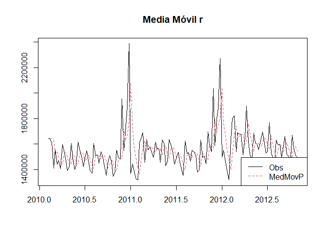

```r
fr<-movavg(y,2,type="r")
frt<-rep(0,143)
for(t in 2:143) frt[t]<-fr[t-1]
for(t in 1) frt[t]<-NA
fr_ts<-rep(0,143)
fr_ts<-ts(frt,start = decimal_date(as.Date("2010-02-05")), frequency = 52)

ts.plot(y,fr_ts,xlab=NULL,ylab=NULL, main = "Media Móvil r",lty=c(1:2),col=c(1,2))
legend(x="bottomright",legend=c("Obs","MedMovP"),col=c(1,2),lty=c(1,2))
```

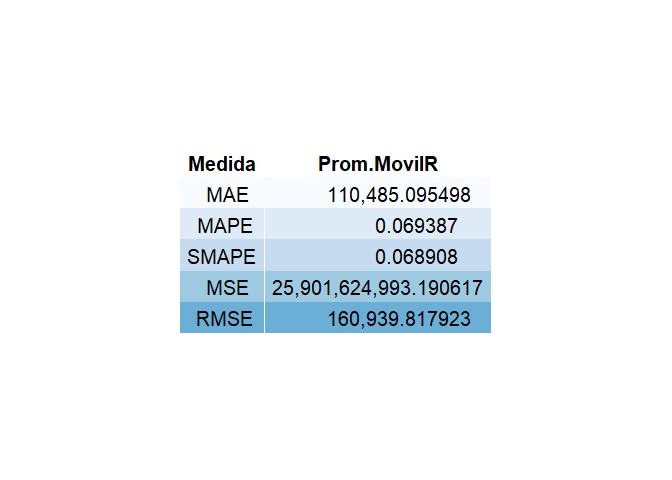

```r
yr_ob<-rep(0,142)
for (t in 1:142) yr_ob[t]<-y[t+1]
yr_pr<-rep(0,142)
for (t in 1:142) yr_pr[t]<-fr[t]
mae_yr<-MAE(yr_ob,yr_pr)
mape_yr<-MAPE(yr_ob,yr_pr)
smape_yr<-SMAPE(yr_ob,yr_pr)
mse_yr<-MSE(yr_ob,yr_pr)
rmse_yr<-RMSE(yr_ob,yr_pr)

medidas <- matrix(c(mae_yr,mape_yr,smape_yr,mse_yr,rmse_yr));
rownames(medidas) <- c('MAE','MAPE','SMAPE','MSE','RMSE')
colnames(medidas)<-c("Prom.MovilR")
df_medidas <- as.data.frame(medidas)

tab_medidas <- as.data.table(df_medidas, keep.rownames=TRUE, keep.colnames=FALSE)
colnames(tab_medidas) <- c("Medida","Prom.MovilR")
ftab_medidas <- format(tab_medidas, digits=5, scientific = F, big.mark=",",decimal.mark=".",justify="right")
tem <- ttheme_minimal(base_colour="black",base_size=15, core=list(bg_params=list(fill=blues9,col=NA)))

grid.arrange(tableGrob(ftab_medidas,theme=tem))
```

## Promedio móvil doble

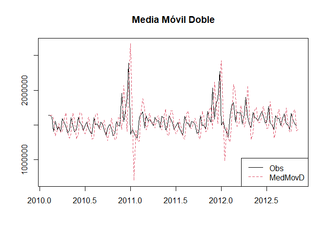

```r
y <- ts(info_tda_1$Weekly_Sales, start = decimal_date(as.Date("2010-02-05")), frequency = 52)

m1<-movavg(y, 2, type=c("s"))
m2<-movavg(m1,2, type=c("s"))
b<-(2/1)*(m1-m2)
a = 2*m1-m2
f<-a+b*1

# Grafica
fdt<-rep(0,144)
for(t in 2:144) fdt[t]<-f[t-1]
for(t in 1) fdt[t]<-NA
fd_ts<-rep(0,144)
fd_ts<-ts(fdt,start = decimal_date(as.Date("2010-02-05")), frequency = 52)
ts.plot(y,fd_ts,xlab=NULL,ylab=NULL, main = "Media Móvil Doble",lty=c(1:2),col=c(1,2))
legend(x="bottomright",legend=c("Obs","MedMovD"),col=c(1,2),lty=c(1,2))
```

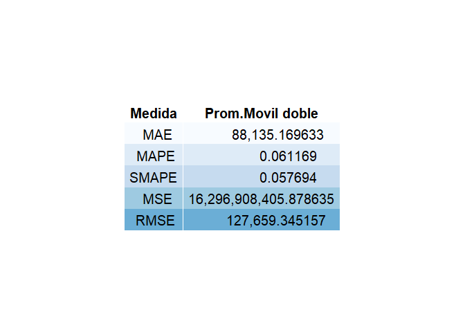

```r
yd_pr<-rep(0,143)
for (t in 1:143) yd_pr[t]<-f[t]
mae_yd<-MAE(y,yd_pr)
mape_yd<-MAPE(y,yd_pr)
smape_yd<-SMAPE(y,yd_pr)
mse_yd<-MSE(y,yd_pr)
rmse_yd<-RMSE(y,yd_pr)

medidas <- matrix(c(mae_yd,mape_yd,smape_yd,mse_yd,rmse_yd));
rownames(medidas) <- c('MAE','MAPE','SMAPE','MSE','RMSE')
colnames(medidas)<-c("Prom.Movil doble")
df_medidas <- as.data.frame(medidas)

tab_medidas <- as.data.table(df_medidas, keep.rownames=TRUE, keep.colnames=FALSE)
colnames(tab_medidas) <- c("Medida","Prom.Movil doble")
ftab_medidas <- format(tab_medidas, digits=5, scientific = F, big.mark=",",decimal.mark=".",justify="right")
tem <- ttheme_minimal(base_colour="black",base_size=15, core=list(bg_params=list(fill=blues9,col=NA)))

grid.arrange(tableGrob(ftab_medidas,theme=tem))
```

## Promedio móvil triangular

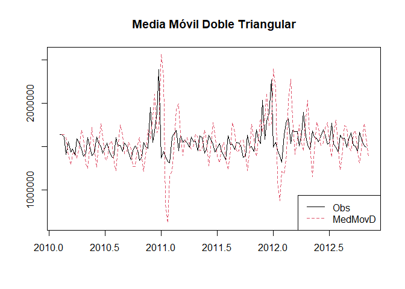

```r
y <- ts(info_tda_1$Weekly_Sales, start = decimal_date(as.Date("2010-02-05")), frequency = 52)

m1<-movavg(y, 2, type=c("t"))
m2<-movavg(m1,2, type=c("t"))
b<-(2/1)*(m1-m2)
a = 2*m1-m2
f<-a+b*1

# Grafica
fdt<-rep(0,144)
for(t in 2:144) fdt[t]<-f[t-1]
for(t in 1) fdt[t]<-NA
fd_ts<-rep(0,144)
fd_ts<-ts(fdt,start = decimal_date(as.Date("2010-02-05")), frequency = 52)
ts.plot(y,fd_ts,xlab=NULL,ylab=NULL, main = "Media Móvil Doble Triangular",lty=c(1:2),col=c(1,2))
legend(x="bottomright",legend=c("Obs","MedMovD"),col=c(1,2),lty=c(1,2))
```

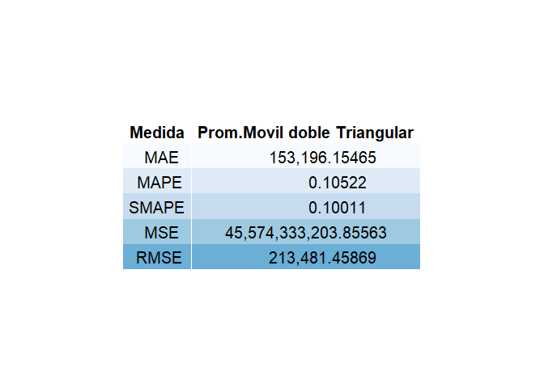

```r
yd_pr<-rep(0,143)
for (t in 1:143) yd_pr[t]<-f[t]
mae_yd<-MAE(y,yd_pr)
mape_yd<-MAPE(y,yd_pr)
smape_yd<-SMAPE(y,yd_pr)
mse_yd<-MSE(y,yd_pr)
rmse_yd<-RMSE(y,yd_pr)

medidas <- matrix(c(mae_yd,mape_yd,smape_yd,mse_yd,rmse_yd));
rownames(medidas) <- c('MAE','MAPE','SMAPE','MSE','RMSE')
colnames(medidas)<-c("Prom.Movil doble Triangular")
df_medidas <- as.data.frame(medidas)

tab_medidas <- as.data.table(df_medidas, keep.rownames=TRUE, keep.colnames=FALSE)
colnames(tab_medidas) <- c("Medida","Prom.Movil doble Triangular")
ftab_medidas <- format(tab_medidas, digits=5, scientific = F, big.mark=",",decimal.mark=".",justify="right")
tem <- ttheme_minimal(base_colour="black",base_size=15, core=list(bg_params=list(fill=blues9,col=NA)))

grid.arrange(tableGrob(ftab_medidas,theme=tem))
```

## Promedio móvil doble modificado

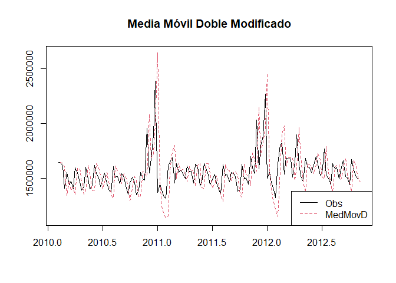

```r
y <- ts(info_tda_1$Weekly_Sales, start = decimal_date(as.Date("2010-02-05")), frequency = 52)

m1<-movavg(y, 2, type=c("m"))
m2<-movavg(m1,2, type=c("m"))
b<-(2/1)*(m1-m2)
a = 2*m1-m2
f<-a+b*1

# Grafica
fdt<-rep(0,144)
for(t in 2:144) fdt[t]<-f[t-1]
for(t in 1) fdt[t]<-NA
fd_ts<-rep(0,144)
fd_ts<-ts(fdt,start = decimal_date(as.Date("2010-02-05")), frequency = 52)
ts.plot(y,fd_ts,xlab=NULL,ylab=NULL, main = "Media Móvil Doble Modificado",lty=c(1:2),col=c(1,2))
legend(x="bottomright",legend=c("Obs","MedMovD"),col=c(1,2),lty=c(1,2))
```

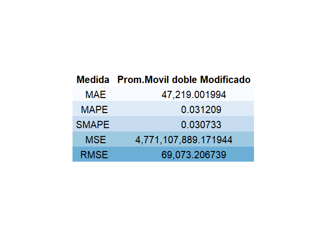

```r
yd_pr<-rep(0,143)
for (t in 1:143) yd_pr[t]<-f[t]
mae_yd<-MAE(y,yd_pr)
mape_yd<-MAPE(y,yd_pr)
smape_yd<-SMAPE(y,yd_pr)
mse_yd<-MSE(y,yd_pr)
rmse_yd<-RMSE(y,yd_pr)

medidas <- matrix(c(mae_yd,mape_yd,smape_yd,mse_yd,rmse_yd));
rownames(medidas) <- c('MAE','MAPE','SMAPE','MSE','RMSE')
colnames(medidas)<-c("Prom.Movil doble Modificado")
df_medidas <- as.data.frame(medidas)

tab_medidas <- as.data.table(df_medidas, keep.rownames=TRUE, keep.colnames=FALSE)
colnames(tab_medidas) <- c("Medida","Prom.Movil doble Modificado")
ftab_medidas <- format(tab_medidas, digits=5, scientific = F, big.mark=",",decimal.mark=".",justify="right")
tem <- ttheme_minimal(base_colour="black",base_size=15, core=list(bg_params=list(fill=blues9,col=NA)))

grid.arrange(tableGrob(ftab_medidas,theme=tem))
```